# Credit Scoring

Loan default can be defined as the inability of a borrower to fulfill his or her loan obligation as at when due Default loans cost a lot on a bank on the way of its progress. It- Diminishes Asset Quality, Increases the Cost of Funds, Decreases the Profitability of the Bank, Decreases the Overall Credit Rating of the Bank

# R Packages

I have used below list of R packages in this project

```r
library(DT)          # For Data Tables
```

```r
library(lattice)     # The lattice add-on of Trellis graphics for R
library(knitr)       # For Dynamic Report Generation in R
library(gplots)      # Various R Programming Tools for Plotting Data
library(ggplot2)     # An Implementation of the Grammar of Graphics
library(ClustOfVar)  # Clustering of variables
library(ape)         # Analyses of Phylogenetics and Evolution (as.phylo)
library(Information) # Data Exploration with Information Theory (Weight-of-Evidence and Information Value)
library(ROCR)        # Model Performance and ROC curve
library(caret)       # Classification and Regression Training -  for any machine learning algorithms
library(rpart)       # Recursive partitioning for classification, regression and survival trees
library(rpart.utils) # Tools for parsing and manipulating rpart objects, including generating machine readable rules
library(rpart.plot)  # Plot 'rpart' Models: An Enhanced Version of 'plot.rpart'
library(randomForest)# Leo Breiman and Cutler's Random Forests for Classification and Regression
library(party)       # A computational toolbox for recursive partitioning - Conditional inference Trees
library(bnlearn)     # Bayesian Network Structure Learning, Parameter Learning and Inference
library(DAAG)        # Data Analysis and Graphics Data and Functions
library(vcd)         # Visualizing Categorical Data
library(kernlab)     # Support Vector Machine
library(ROSE)        # Sampling Analysis
library(dplyr)       # EDA
library(tidyverse)   # EDA
```

# Import Data Set

```r
Credit_Scoring <- read.csv("C:/Users/Ronald Muhammad/Downloads/credit scoring train.csv")
```

# Get first hand feeling of the data

```r
#Check Colnames
kable (as.data.frame (colnames(Credit_Scoring)))
```

| colnames(Credit_Scoring) |
| --- |
| X |
| jumlah_kartu |
| outstanding |
| limit_kredit |
| tagihan |
| total_pemakaian_tunai |
| total_pemakaian_retail |
| sisa_tagihan_tidak_terbayar |
| kode_cabang |
| rasio_pembayaran |
| persentasi_overlimit |
| rasio_pembayaran_3bulan |
| rasio_pembayaran_6bulan |
| skor_delikuensi |
| flag_kredit_macet |
| jumlah_tahun_sejak_pembukaan_kredit |
| total_pemakaian |
| sisa_tagihan_per_jumlah_kartu |
| sisa_tagihan_per_limit |
| total_pemakaian_per_limit |
| pemakaian_3bln_per_limit |
| pemakaian_6bln_per_limit |
| utilisasi_3bulan |
| utilisasi_6bulan |

```r
#Understand the strucutre of data
str(Credit_Scoring)
```

```
## 'data.frame':    15493 obs. of  24 variables:
##  $ X                                  : int  1 2 3 4 5 6 7 8 9 10 ...
##  $ jumlah_kartu                       : int  2 2 3 4 2 2 2 4 2 4 ...
##  $ outstanding                        : int  36158 268691 6769149 3496732 9402085 6227439 3906290 9534837 4145065 1818606 ...
##  $ limit_kredit                       : num  7.0e+06 1.0e+07 2.8e+07 2.1e+07 1.0e+07 8.0e+07 4.0e+06 2.0e+07 5.0e+06 7.0e+06 ...
##  $ tagihan                            : num  23437 254564 4159779 111231 6099283 ...
##  $ total_pemakaian_tunai              : num  0 0 0 0 0 0 0 0 0 0 ...
##  $ total_pemakaian_retail             : num  94 1012 0 2536660 2666558 ...
##  $ sisa_tagihan_tidak_terbayar        : num  26323 0 0 581334 5951865 ...
##  $ kode_cabang                        : chr  "I" "A" "A" "G" ...
##  $ rasio_pembayaran                   : num  102 0 100 100 96 ...
##  $ persentasi_overlimit               : num  0 0 0 0 0 0 0 0 0 0 ...
##  $ rasio_pembayaran_3bulan            : num  74.8 0 100 25 97.5 ...
##  $ rasio_pembayaran_6bulan            : num  100 0 100.9 22.6 99.8 ...
##  $ skor_delikuensi                    : int  0 0 0 0 0 0 0 0 0 0 ...
##  $ flag_kredit_macet                  : int  0 0 0 0 0 0 0 0 0 0 ...
##  $ jumlah_tahun_sejak_pembukaan_kredit: num  15.42 0.75 10.75 19.75 1.67 ...
##  $ total_pemakaian                    : num  94 1012 0 2536660 2666558 ...
##  $ sisa_tagihan_per_jumlah_kartu      : num  13162 0 0 145334 2975933 ...
##  $ sisa_tagihan_per_limit             : num  0.00376 0 0 0.02768 0.59519 ...
##  $ total_pemakaian_per_limit          : num  1.34e-05 1.01e-04 0.00 1.21e-01 2.67e-01 ...
##  $ pemakaian_3bln_per_limit           : num  0.0117 0 0.0405 0.056 0.323 ...
##  $ pemakaian_6bln_per_limit           : num  0.0178 0 0.0477 0.0169 0.1312 ...
##  $ utilisasi_3bulan                   : num  0.01323 0.00423 0.24939 0.10191 0.70787 ...
##  $ utilisasi_6bulan                   : num  0.0219 0.0003 0.2679 0.3466 0.3366 ...
```

```r
## we found Kode_cabang is in chr format
unique(Credit_Scoring$kode_cabang)
```

```
##  [1] "I" "A" "G" "B" "E" "K" "F" "C" "J" "H" ""  "D"
```

```r
#Summary of the variable
summary(Credit_Scoring)
```

```
##        X          jumlah_kartu     outstanding         limit_kredit
##  Min.   :    1   Min.   : 1.000   Min.   :        0   Min.   :3.00e+06
##  1st Qu.: 3874   1st Qu.: 2.000   1st Qu.:  2000551   1st Qu.:5.00e+06
##  Median : 7747   Median : 2.000   Median :  4726943   Median :9.00e+06
##  Mean   : 7747   Mean   : 2.507   Mean   : 11598331   Mean   :2.08e+07
##  3rd Qu.:11620   3rd Qu.: 3.000   3rd Qu.: 10648482   3rd Qu.:2.20e+07
##  Max.   :15493   Max.   :16.000   Max.   :798058574   Max.   :1.00e+09
##     tagihan          total_pemakaian_tunai total_pemakaian_retail
##  Min.   :    20043   Min.   :       0      Min.   :-15667200
##  1st Qu.:   818250   1st Qu.:       0      1st Qu.:        0
##  Median :  3145857   Median :       0      Median :   201042
##  Mean   :  8078663   Mean   :   74533      Mean   :  2025857
##  3rd Qu.:  7404991   3rd Qu.:       0      3rd Qu.:  1398000
##  Max.   :628000000   Max.   :28840572      Max.   :285000000
##  sisa_tagihan_tidak_terbayar kode_cabang        rasio_pembayaran
##  Min.   :        0           Length:15493       Min.   :-18138.00
##  1st Qu.:        0           Class :character   1st Qu.:     0.00
##  Median :  2750923           Mode  :character   Median :    27.00
##  Mean   :  8140875                              Mean   :    64.65
##  3rd Qu.:  7143198                              3rd Qu.:   100.00
##  Max.   :444000000                              Max.   : 68983.00
##  persentasi_overlimit rasio_pembayaran_3bulan rasio_pembayaran_6bulan
##  Min.   :  0.000      Min.   :-57792.34       Min.   :-77056.00
##  1st Qu.:  0.000      1st Qu.:    20.20       1st Qu.:    21.60
##  Median :  0.000      Median :    50.00       Median :    65.60
##  Mean   :  3.344      Mean   :    50.53       Mean   :    81.67
##  3rd Qu.:  1.060      3rd Qu.:    91.37       3rd Qu.:   100.00
##  Max.   :190.000      Max.   : 75575.00       Max.   : 54899.00
##  skor_delikuensi    flag_kredit_macet jumlah_tahun_sejak_pembukaan_kredit
##  Min.   :0.000000   Min.   :0.00000   Min.   : 0.750
##  1st Qu.:0.000000   1st Qu.:0.00000   1st Qu.: 2.920
##  Median :0.000000   Median :0.00000   Median : 5.667
##  Mean   :0.004776   Mean   :0.08772   Mean   : 6.634
##  3rd Qu.:0.000000   3rd Qu.:0.00000   3rd Qu.: 9.330
##  Max.   :5.000000   Max.   :1.00000   Max.   :34.417
##  total_pemakaian     sisa_tagihan_per_jumlah_kartu sisa_tagihan_per_limit
##  Min.   :-15667200   Min.   :        0             Min.   :0.0000
##  1st Qu.:        0   1st Qu.:        0             1st Qu.:0.0000
##  Median :   248000   Median :  1209318             Median :0.3350
##  Mean   :  2100421   Mean   :  2968060             Mean   :0.4682
##  3rd Qu.:  1512235   3rd Qu.:  3088477             3rd Qu.:0.9300
##  Max.   :314000000   Max.   :148000000             Max.   :7.2400
##  total_pemakaian_per_limit pemakaian_3bln_per_limit pemakaian_6bln_per_limit
##  Min.   :-0.6320           Min.   :-0.1260          Min.   :-0.5690
##  1st Qu.: 0.0000           1st Qu.: 0.0352          1st Qu.: 0.0329
##  Median : 0.0221           Median : 0.1080          Median : 0.1170
##  Mean   : 0.1094           Mean   : 0.1674          Mean   : 0.2026
##  3rd Qu.: 0.1280           3rd Qu.: 0.2390          3rd Qu.: 0.2850
##  Max.   : 4.6000           Max.   : 3.4900          Max.   : 8.1100
##  utilisasi_3bulan   utilisasi_6bulan
##  Min.   :0.000288   Min.   :0.0000
##  1st Qu.:0.189000   1st Qu.:0.1550
##  Median :0.575000   Median :0.4960
##  Mean   :0.571102   Mean   :0.5337
##  3rd Qu.:0.917000   3rd Qu.:0.8630
##  Max.   :8.125671   Max.   :9.7300
```

```r
## Column x seems similar with the number indexing, so we should take out this coloumn
Credit_Scoring <- subset(Credit_Scoring, select = -X)
```

```r
#checking the data
DT::datatable(Credit_Scoring[1:100,])
```

|  | jumlah_kartu | outstanding | limit_kredit | tagihan | total_pemakaian_tunai | total_pemakaian_retail | sisa_tagihan_tidak_terbayar | kode_cabang | rasio_pembayaran | persentasi_overlimit | rasio_pembayaran_3bulan | rasio_pembayaran_6bulan | skor_delikuensi | flag_kredit_macet | jumlah_tahun_sejak_pembukaan_kredit | total_pemakaian | sisa_tagihan_per_jumlah_kartu | sisa_tagihan_per_limit | total_pemakaian_per_limit | pemakaian_3bln_per_limit | pemakaian_6bln_per_limit | utilisasi_3bulan | utilisasi_6bulan |
| --- | --- | --- | --- | --- | --- | --- | --- | --- | --- | --- | --- | --- | --- | --- | --- | --- | --- | --- | --- | --- | --- | --- | --- |
| 1 | 2 | 36158 | 7000000 | 23437 | 0 | 94 | 26323 | I | 102.19 | 0 | 74.78 | 100 | 0 | 0 | 15.41666667 | 94 | 13161.5 | 0.003760429 | 1.34e-05 | 0.01171875 | 0.017809524 | 0.013228036 | 0.021949333 |
| 2 | 2 | 268691 | 10000000 | 254564 | 0 | 1012 | 0 | A | 0 | 0 | 0 | 0 | 0 | 0 | 0.75 | 1012 | 0 | 0 | 0.0001012 | 0 | 0 | 0.004231625 | 0.0003 |
| 3 | 3 | 6769149 | 28000000 | 4159779 | 0 | 0 | 0 | A | 100 | 0 | 100 | 100.91 | 0 | 0 | 10.75 | 0 | 0 | 0 | 0 | 0.040517857 | 0.047703226 | 0.249389277 | 0.267852798 |
| 4 | 4 | 3496732 | 21000000 | 111231 | 0 | 2536660 | 581334 | G | 100 | 0 | 25.01 | 22.64 | 0 | 0 | 19.75 | 2536660 | 145333.5 | 0.027682571 | 0.120793333 | 0.055970595 | 0.016850794 | 0.101912107 | 0.346634603 |
| 5 | 2 | 9402085 | 10000000 | 6099283 | 0 | 2666558 | 5951865 | A | 95.99 | 0 | 97.49 | 99.84 | 0 | 0 | 1.666666667 | 2666558 | 2975932.5 | 0.5951865 | 0.2666558 | 0.323027 | 0.131162467 | 0.707865025 | 0.336571367 |
| 6 | 2 | 6227439 | 80000000 | 2081248 | 0 | 3690250 | 4613435 | A | 0 | 0 | 28.46 | 42.03 | 0 | 0 | 10.25 | 3690250 | 2306717.5 | 0.057667938 | 0.046128125 | 0.017184375 | 0.117513096 | 0.038963606 | 0.181863421 |
| 7 | 2 | 3906290 | 4000000 | 2043682 | 0 | 230400 | 3314046 | A | 18.47 | 0 | 24.95 | 17.89 | 0 | 0 | 4.666666667 | 230400 | 1657023 | 0.8285115 | 0.0576 | 0.01875 | 0.166666668 | 1.014775813 | 0.977230833 |
| 8 | 4 | 9534837 | 20000000 | 3692028 | 0 | 9327612 | 7881069 | A | 58.55 | 0 | 105.24 | 166.67 | 0 | 0 | 0.75 | 9327612 | 1970267.25 | 0.39405345 | 0.4663806 | 0.2392893 | 0.241598694 | 0.261753338 | 0.22402625 |
| 9 | 2 | 4145065 | 5000000 | 4021399 | 0 | 335680 | 4122425 | B | 15.24 | 0 | 0 | 33.33 | 0 | 0 | 5.666666667 | 335680 | 2061212.5 | 0.824485 | 0.067136 | 0.19604205 | 0 | 0.47002435 | 0 |
| 10 | 4 | 1818606 | 7000000 | 1765911 | 0 | 0 | 1627786 | A | 100 | 0 | 58.4 | 62.68 | 0 | 0 | 8.5 | 0 | 406946.5 | 0.232540857 | 0 | 0.075 | 0.094800619 | 0.315145179 | 0.626447904 |

[output cut: 90 more lines]

```r
head(Credit_Scoring)
```

```
##   jumlah_kartu outstanding limit_kredit tagihan total_pemakaian_tunai
## 1            2       36158      7.0e+06   23437                     0
## 2            2      268691      1.0e+07  254564                     0
## 3            3     6769149      2.8e+07 4159779                     0
## 4            4     3496732      2.1e+07  111231                     0
## 5            2     9402085      1.0e+07 6099283                     0
## 6            2     6227439      8.0e+07 2081248                     0
##   total_pemakaian_retail sisa_tagihan_tidak_terbayar kode_cabang
## 1                     94                       26323           I
## 2                   1012                           0           A
## 3                      0                           0           A
## 4                2536660                      581334           G
## 5                2666558                     5951865           A
## 6                3690250                     4613435           A
##   rasio_pembayaran persentasi_overlimit rasio_pembayaran_3bulan
```

[output cut: 41 more lines]

```r
#checking the missing value, the result shows no missing value found in this data set
colSums(is.na(Credit_Scoring))
```

```
##                        jumlah_kartu                         outstanding
##                                   0                                   0
##                        limit_kredit                             tagihan
##                                   0                                   0
##               total_pemakaian_tunai              total_pemakaian_retail
##                                   0                                   0
##         sisa_tagihan_tidak_terbayar                         kode_cabang
##                                   0                                   0
##                    rasio_pembayaran                persentasi_overlimit
##                                   0                                   0
##             rasio_pembayaran_3bulan             rasio_pembayaran_6bulan
##                                   0                                   0
##                     skor_delikuensi                   flag_kredit_macet
##                                   0                                   0
## jumlah_tahun_sejak_pembukaan_kredit                     total_pemakaian
##                                   0                                   0
##       sisa_tagihan_per_jumlah_kartu              sisa_tagihan_per_limit
##                                   0                                   0
##           total_pemakaian_per_limit            pemakaian_3bln_per_limit
##                                   0                                   0
##            pemakaian_6bln_per_limit                    utilisasi_3bulan
##                                   0                                   0
##                    utilisasi_6bulan
##                                   0
```

#Data Analysis & Variable Creation ## Analysis of our response / target variable where 1 is default and 0 is not default

```r
Credit_Scoring$flag_kredit_macet <- as.factor(ifelse (Credit_Scoring$flag_kredit_macet == 0, "Good", "Default"))

unique(Credit_Scoring$flag_kredit_macet)
```

```
## [1] Good    Default
## Levels: Default Good
```

```r
Credit_Scoring %>%
  group_by(flag_kredit_macet) %>%
  summarise(percent = 100 * n () / nrow(Credit_Scoring))
```

```
## # A tibble: 2 x 2
##   flag_kredit_macet percent
##   <fct>               <dbl>
## 1 Default              8.77
## 2 Good                91.2
```

```r
op<-par(mfrow=c(1,2), new=TRUE)
```

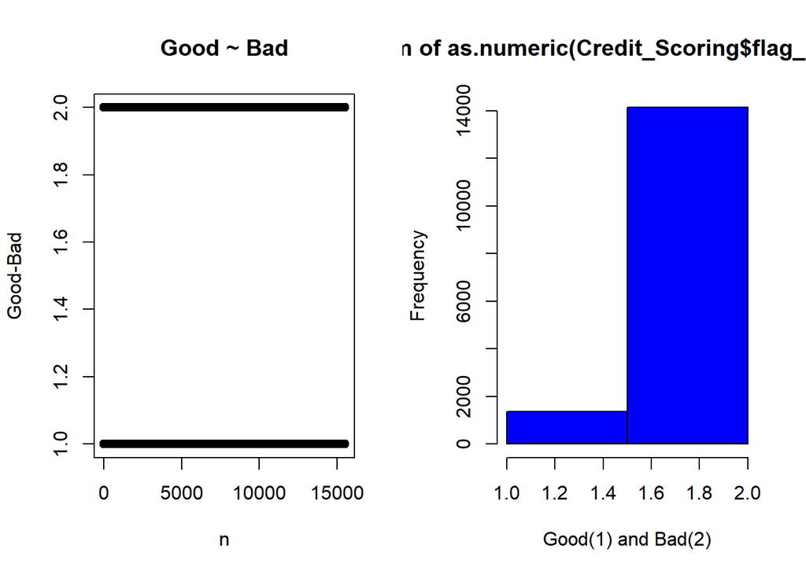

```r
plot(as.numeric(Credit_Scoring$flag_kredit_macet), ylab="Good-Bad", xlab="n", main="Good ~ Bad")
hist(as.numeric(Credit_Scoring$flag_kredit_macet), breaks=2,
     xlab="Good(1) and Bad(2)", col="blue")
```

```r
table(Credit_Scoring$flag_kredit_macet)
```

```
##
## Default    Good
##    1359   14134
```

```r
prop.table(table(Credit_Scoring$flag_kredit_macet))
```

```
##
##    Default       Good
## 0.08771703 0.91228297
```

```r
par(op)
```

#Weight of Evidence (WOE) & Invormation Value (IV) ##WOE will shows predictive power of an independent variable in relation to dependent variable ## Information Value helps to select variables by using their order of importance

```r
Credit_Scoring$flag_kredit_macet<-as.numeric(ifelse(Credit_Scoring$flag_kredit_macet == "Good", 0, 1))
IV <- Information::create_infotables(data=Credit_Scoring, NULL, y="flag_kredit_macet", 10)
IV$Summary$IV <- round(IV$Summary$IV*100,2)

IV$Tables
```

```
## $jumlah_kartu
##   jumlah_kartu     N     Percent         WOE           IV
## 1        [1,1]    76 0.004905441  0.33436607 0.0006293352
## 2        [2,2] 10734 0.692829020 -0.04332343 0.0019067039
## 3        [3,3]  2795 0.180404053  0.02579412 0.0020280167
## 4       [4,16]  1888 0.121861486  0.17484439 0.0060318110
##
## $outstanding
##             outstanding    N    Percent          WOE        IV
## 1            [0,339343] 1548 0.09991609  1.000947786 0.1495327
## 2      [340993,1350109] 1549 0.09998064 -1.058696386 0.2228629
## 3     [1351974,2596129] 1550 0.10004518 -1.168051580 0.3085608
## 4     [2596654,3470469] 1549 0.09998064 -0.386362659 0.3212984
## 5     [3471504,4725195] 1548 0.09991609 -0.385674665 0.3339861
## 6     [4726862,6027873] 1550 0.10004518 -0.007775925 0.3339922
```

[output cut: 220 more lines]

```r
kable(IV$Summary)
```

|  | Variable | IV |
| --- | --- | --- |
| 6 | total_pemakaian_retail | 81.03 |
| 9 | rasio_pembayaran | 78.51 |
| 15 | total_pemakaian | 70.98 |
| 18 | total_pemakaian_per_limit | 70.82 |
| 11 | rasio_pembayaran_3bulan | 70.46 |
| 21 | utilisasi_3bulan | 59.42 |
| 4 | tagihan | 47.93 |
| 2 | outstanding | 38.57 |
| 22 | utilisasi_6bulan | 31.68 |
| 12 | rasio_pembayaran_6bulan | 30.55 |
| 17 | sisa_tagihan_per_limit | 28.92 |
| 19 | pemakaian_3bln_per_limit | 27.94 |
| 10 | persentasi_overlimit | 23.69 |
| 7 | sisa_tagihan_tidak_terbayar | 17.00 |
| 16 | sisa_tagihan_per_jumlah_kartu | 16.67 |
| 20 | pemakaian_6bln_per_limit | 8.15 |
| 14 | jumlah_tahun_sejak_pembukaan_kredit | 7.30 |
| 8 | kode_cabang | 1.71 |
| 3 | limit_kredit | 0.95 |
| 1 | jumlah_kartu | 0.60 |
| 13 | skor_delikuensi | 0.31 |
| 5 | total_pemakaian_tunai | 0.00 |

#Analysis best variable combination before performing the model We will use the variable with IV > 2% due to the predictor has a weak relationship to the Good / Default odds ratio

```r
#sub-setting the variable with IV < 2%

Credit_Scoring <- subset(Credit_Scoring, select = -c(total_pemakaian_tunai,skor_delikuensi,jumlah_kartu,limit_kredit,kode_cabang))

str(Credit_Scoring)
```

```
## 'data.frame':    15493 obs. of  18 variables:
##  $ outstanding                        : int  36158 268691 6769149 3496732 9402085 6227439 3906290 9534837 4145065 1818606 ...
##  $ tagihan                            : num  23437 254564 4159779 111231 6099283 ...
##  $ total_pemakaian_retail             : num  94 1012 0 2536660 2666558 ...
##  $ sisa_tagihan_tidak_terbayar        : num  26323 0 0 581334 5951865 ...
##  $ rasio_pembayaran                   : num  102 0 100 100 96 ...
##  $ persentasi_overlimit               : num  0 0 0 0 0 0 0 0 0 0 ...
##  $ rasio_pembayaran_3bulan            : num  74.8 0 100 25 97.5 ...
##  $ rasio_pembayaran_6bulan            : num  100 0 100.9 22.6 99.8 ...
##  $ flag_kredit_macet                  : num  0 0 0 0 0 0 0 0 0 0 ...
##  $ jumlah_tahun_sejak_pembukaan_kredit: num  15.42 0.75 10.75 19.75 1.67 ...
##  $ total_pemakaian                    : num  94 1012 0 2536660 2666558 ...
##  $ sisa_tagihan_per_jumlah_kartu      : num  13162 0 0 145334 2975933 ...
##  $ sisa_tagihan_per_limit             : num  0.00376 0 0 0.02768 0.59519 ...
##  $ total_pemakaian_per_limit          : num  1.34e-05 1.01e-04 0.00 1.21e-01 2.67e-01 ...
##  $ pemakaian_3bln_per_limit           : num  0.0117 0 0.0405 0.056 0.323 ...
##  $ pemakaian_6bln_per_limit           : num  0.0178 0 0.0477 0.0169 0.1312 ...
##  $ utilisasi_3bulan                   : num  0.01323 0.00423 0.24939 0.10191 0.70787 ...
##  $ utilisasi_6bulan                   : num  0.0219 0.0003 0.2679 0.3466 0.3366 ...
```

```r
Credit_Scoring$outstanding <- as.numeric(Credit_Scoring$outstanding)
Credit_Scoring$flag_kredit_macet <-as.numeric(Credit_Scoring$flag_kredit_macet)
```

#Since we know this data set categorized as “IMBALANCE DATA SET”, then we need to perform some sampling method to define which sampling method is the best fit for our modelling

```r
#Over Sampling
data_balanced_over <- ovun.sample(flag_kredit_macet~ ., data = Credit_Scoring, method = "over", N = 15493)$data
table(data_balanced_over$flag_kredit_macet)
```

```
##
##     0     1
## 14134  1359
```

```r
set.seed(123)
sample <-sample(c(TRUE, FALSE), nrow(data_balanced_over), replace = T, prob = c(0.7,0.3))
train_over <- data_balanced_over [sample,]
test_over <- data_balanced_over[!sample,]

#Under Sampling
data_balanced_under <- ovun.sample(flag_kredit_macet~ ., data = Credit_Scoring, method = "under", N = 2718, seed = 123)$data
table(data_balanced_under$flag_kredit_macet)
```

```
##
##    0    1
## 1359 1359
```

```r
set.seed(123)
sample <-sample(c(TRUE, FALSE), nrow(data_balanced_under), replace = T, prob = c(0.7,0.3))
train_under <- data_balanced_under [sample,]
test_under <- data_balanced_under[!sample,]

#Both
data_balanced_both <- ovun.sample(flag_kredit_macet~ ., data = Credit_Scoring, method = "both", p=0.5)$data
table(data_balanced_both$flag_kredit_macet)
```

```
##
##    0    1
## 7833 7660
```

```r
set.seed(123)
sample <-sample(c(TRUE, FALSE), nrow(data_balanced_both), replace = T, prob = c(0.7,0.3))
train_both <- data_balanced_both [sample,]
test_both <- data_balanced_both[!sample,]

#Sampling using ROSE Package -synthetic sampling technique
data_ROSE <- ROSE(flag_kredit_macet~ ., data = Credit_Scoring, seed = 123)$data
table(data_ROSE$flag_kredit_macet)
```

```
##
##    0    1
## 7873 7620
```

```r
set.seed(123)
sample <-sample(c(TRUE, FALSE), nrow(data_ROSE), replace = T, prob = c(0.7,0.3))
train_rose <- data_ROSE [sample,]
test_rose <- data_ROSE[!sample,]

str(train_rose)
```

```
## 'data.frame':    10893 obs. of  18 variables:
##  $ outstanding                        : num  -3933143 -443459 46688133 -6079378 4243696 ...
##  $ tagihan                            : num  314515 -150527 139975938 -12235546 20447320 ...
##  $ total_pemakaian_retail             : num  1721879 -230278 2371946 -10134950 3385235 ...
##  $ sisa_tagihan_tidak_terbayar        : num  5922583 18732896 34497206 28278848 17890840 ...
##  $ rasio_pembayaran                   : num  231.9 -1299.5 491.3 -837.9 99.5 ...
##  $ persentasi_overlimit               : num  -6.253 -2.708 -3.988 0.107 22.078 ...
##  $ rasio_pembayaran_3bulan            : num  -1167.2 653.1 1015.4 -58.4 435.1 ...
##  $ rasio_pembayaran_6bulan            : num  1465 923 814 442 294 ...
##  $ flag_kredit_macet                  : num  0 0 0 0 0 0 0 0 0 0 ...
##  $ jumlah_tahun_sejak_pembukaan_kredit: num  3.61 22.52 10.81 2.87 3.05 ...
##  $ total_pemakaian                    : num  -5939689 -1060414 3002506 -1084069 2982029 ...
##  $ sisa_tagihan_per_jumlah_kartu      : num  -479402 3717896 26026436 1683617 -1507088 ...
##  $ sisa_tagihan_per_limit             : num  0.163 -0.146 -0.648 0.646 -0.319 ...
##  $ total_pemakaian_per_limit          : num  0.2003 0.1292 0.3296 0.0135 1.1478 ...
##  $ pemakaian_3bln_per_limit           : num  0.0508 -0.1457 1.4228 0.4218 0.3591 ...
##  $ pemakaian_6bln_per_limit           : num  0.15 0.131 0.705 0.823 0.361 ...
##  $ utilisasi_3bulan                   : num  -0.154 0.378 0.352 0.502 0.15 ...
##  $ utilisasi_6bulan                   : num  -0.2491 0.5523 -0.0209 0.7818 0.2868 ...
```

```r
str(test_rose)
```

```
## 'data.frame':    4600 obs. of  18 variables:
##  $ outstanding                        : num  28000825 762613 2182870 24271882 -2150725 ...
##  $ tagihan                            : num  5320588 8381693 1417965 18560458 -2222120 ...
##  $ total_pemakaian_retail             : num  12982282 -4467728 6729680 -4394471 -1794780 ...
##  $ sisa_tagihan_tidak_terbayar        : num  -8967720 25349371 -7351427 15325961 12955171 ...
##  $ rasio_pembayaran                   : num  887 357 394 640 303 ...
##  $ persentasi_overlimit               : num  1.02 -5.06 7.69 16.42 -3.29 ...
##  $ rasio_pembayaran_3bulan            : num  -665 -518 665 239 420 ...
##  $ rasio_pembayaran_6bulan            : num  189 -768 -447 1358 110 ...
##  $ flag_kredit_macet                  : num  0 0 0 0 0 0 0 0 0 0 ...
##  $ jumlah_tahun_sejak_pembukaan_kredit: num  5.25 1.04 5.15 13.36 4.93 ...
##  $ total_pemakaian                    : num  -2057 7499636 1500441 2727488 -4635951 ...
##  $ sisa_tagihan_per_jumlah_kartu      : num  -2726158 -2753981 -1791887 8100379 579847 ...
##  $ sisa_tagihan_per_limit             : num  -0.375 -0.305 1.381 1.563 0.36 ...
##  $ total_pemakaian_per_limit          : num  0.0737 0.116 0.5824 -0.0629 0.0169 ...
##  $ pemakaian_3bln_per_limit           : num  0.05473 0.00527 0.66387 0.07267 0.16759 ...
##  $ pemakaian_6bln_per_limit           : num  0.8672 -0.2099 0.4979 0.0654 0.202 ...
##  $ utilisasi_3bulan                   : num  0.733 0.192 0.712 1.209 0.478 ...
##  $ utilisasi_6bulan                   : num  0.4041 -0.1076 0.0127 0.9587 1.3799 ...
```

```r
#lets compare the model using 4 sampling techniques
#In this case I use the decision tree models

tree.rose <-rpart(flag_kredit_macet~ ., data = train_rose)
tree.both <-rpart(flag_kredit_macet~ ., data = train_both)
tree.under <-rpart(flag_kredit_macet~ ., data = train_under)
tree.over <-rpart(flag_kredit_macet~ ., data = train_over)

#Make prediction
pred.tree.rose <-predict(tree.rose, newdata = test_rose)
pred.tree.both <-predict(tree.both, newdata = test_both)
pred.tree.under <-predict(tree.under, newdata = test_under)
pred.tree.over <-predict(tree.over, newdata = test_over)

#check the ROC each sampling techniques

op<-par(mfrow=c(1,4), new=TRUE)
```

```r
roc.curve(test_rose$flag_kredit_macet, pred.tree.rose)
```

```
## Area under the curve (AUC): 0.915
```

```r
roc.curve(test_both$flag_kredit_macet, pred.tree.both)
```

```
## Area under the curve (AUC): 0.808
```

```r
roc.curve(test_under$flag_kredit_macet, pred.tree.under)
```

```
## Area under the curve (AUC): 0.800
```

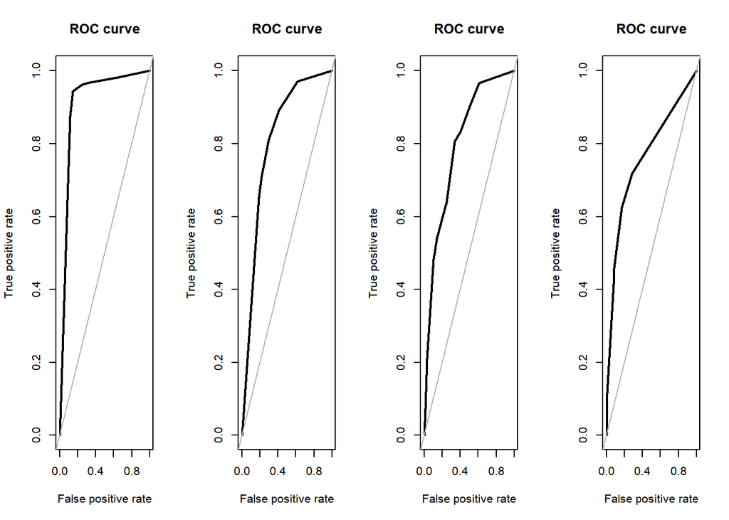

```
## Area under the curve (AUC): 0.760
```

```r
roc.curve(test_over$flag_kredit_macet, pred.tree.over)
```

```r
#check the AUC each sampling techniques
prediction(pred.tree.rose, test_rose$flag_kredit_macet) %>%
  performance(measure = "auc") %>%
  .@y.values
```

```
## [[1]]
## [1] 0.9151313
```

```r
prediction(pred.tree.both, test_both$flag_kredit_macet) %>%
  performance(measure = "auc") %>%
  .@y.values
```

```
## [[1]]
## [1] 0.8082935
```

```r
prediction(pred.tree.under, test_under$flag_kredit_macet) %>%
  performance(measure = "auc") %>%
  .@y.values
```

```
## [[1]]
## [1] 0.7998716
```

```r
prediction(pred.tree.over, test_over$flag_kredit_macet) %>%
  performance(measure = "auc") %>%
  .@y.values
```

```
## [[1]]
## [1] 0.7597691
```

In this comparation, we found that ROSE sampling technique outperformed traditional over & under sampling method. SO we will used this method to our next modeling

The model that I choose are : 1. Logistic regression selected variables 2. Random FOrest 3. SVM

```r
str(Credit_Scoring)
```

```
## 'data.frame':    15493 obs. of  18 variables:
##  $ outstanding                        : num  36158 268691 6769149 3496732 9402085 ...
##  $ tagihan                            : num  23437 254564 4159779 111231 6099283 ...
##  $ total_pemakaian_retail             : num  94 1012 0 2536660 2666558 ...
##  $ sisa_tagihan_tidak_terbayar        : num  26323 0 0 581334 5951865 ...
##  $ rasio_pembayaran                   : num  102 0 100 100 96 ...
##  $ persentasi_overlimit               : num  0 0 0 0 0 0 0 0 0 0 ...
##  $ rasio_pembayaran_3bulan            : num  74.8 0 100 25 97.5 ...
##  $ rasio_pembayaran_6bulan            : num  100 0 100.9 22.6 99.8 ...
##  $ flag_kredit_macet                  : num  0 0 0 0 0 0 0 0 0 0 ...
##  $ jumlah_tahun_sejak_pembukaan_kredit: num  15.42 0.75 10.75 19.75 1.67 ...
##  $ total_pemakaian                    : num  94 1012 0 2536660 2666558 ...
##  $ sisa_tagihan_per_jumlah_kartu      : num  13162 0 0 145334 2975933 ...
##  $ sisa_tagihan_per_limit             : num  0.00376 0 0 0.02768 0.59519 ...
##  $ total_pemakaian_per_limit          : num  1.34e-05 1.01e-04 0.00 1.21e-01 2.67e-01 ...
##  $ pemakaian_3bln_per_limit           : num  0.0117 0 0.0405 0.056 0.323 ...
##  $ pemakaian_6bln_per_limit           : num  0.0178 0 0.0477 0.0169 0.1312 ...
##  $ utilisasi_3bulan                   : num  0.01323 0.00423 0.24939 0.10191 0.70787 ...
##  $ utilisasi_6bulan                   : num  0.0219 0.0003 0.2679 0.3466 0.3366 ...
```

```r
Credit_Scoring$flag_kredit_macet <- as.numeric(Credit_Scoring$flag_kredit_macet)

str(Credit_Scoring)
```

```
## 'data.frame':    15493 obs. of  18 variables:
##  $ outstanding                        : num  36158 268691 6769149 3496732 9402085 ...
##  $ tagihan                            : num  23437 254564 4159779 111231 6099283 ...
##  $ total_pemakaian_retail             : num  94 1012 0 2536660 2666558 ...
##  $ sisa_tagihan_tidak_terbayar        : num  26323 0 0 581334 5951865 ...
##  $ rasio_pembayaran                   : num  102 0 100 100 96 ...
##  $ persentasi_overlimit               : num  0 0 0 0 0 0 0 0 0 0 ...
##  $ rasio_pembayaran_3bulan            : num  74.8 0 100 25 97.5 ...
##  $ rasio_pembayaran_6bulan            : num  100 0 100.9 22.6 99.8 ...
##  $ flag_kredit_macet                  : num  0 0 0 0 0 0 0 0 0 0 ...
##  $ jumlah_tahun_sejak_pembukaan_kredit: num  15.42 0.75 10.75 19.75 1.67 ...
##  $ total_pemakaian                    : num  94 1012 0 2536660 2666558 ...
##  $ sisa_tagihan_per_jumlah_kartu      : num  13162 0 0 145334 2975933 ...
##  $ sisa_tagihan_per_limit             : num  0.00376 0 0 0.02768 0.59519 ...
##  $ total_pemakaian_per_limit          : num  1.34e-05 1.01e-04 0.00 1.21e-01 2.67e-01 ...
##  $ pemakaian_3bln_per_limit           : num  0.0117 0 0.0405 0.056 0.323 ...
##  $ pemakaian_6bln_per_limit           : num  0.0178 0 0.0477 0.0169 0.1312 ...
##  $ utilisasi_3bulan                   : num  0.01323 0.00423 0.24939 0.10191 0.70787 ...
##  $ utilisasi_6bulan                   : num  0.0219 0.0003 0.2679 0.3466 0.3366 ...
```

# 1. LOGISTIC REGRESSION

```r
str(Credit_Scoring)
```

```
## 'data.frame':    15493 obs. of  18 variables:
##  $ outstanding                        : num  36158 268691 6769149 3496732 9402085 ...
##  $ tagihan                            : num  23437 254564 4159779 111231 6099283 ...
##  $ total_pemakaian_retail             : num  94 1012 0 2536660 2666558 ...
##  $ sisa_tagihan_tidak_terbayar        : num  26323 0 0 581334 5951865 ...
##  $ rasio_pembayaran                   : num  102 0 100 100 96 ...
##  $ persentasi_overlimit               : num  0 0 0 0 0 0 0 0 0 0 ...
##  $ rasio_pembayaran_3bulan            : num  74.8 0 100 25 97.5 ...
##  $ rasio_pembayaran_6bulan            : num  100 0 100.9 22.6 99.8 ...
##  $ flag_kredit_macet                  : num  0 0 0 0 0 0 0 0 0 0 ...
##  $ jumlah_tahun_sejak_pembukaan_kredit: num  15.42 0.75 10.75 19.75 1.67 ...
##  $ total_pemakaian                    : num  94 1012 0 2536660 2666558 ...
##  $ sisa_tagihan_per_jumlah_kartu      : num  13162 0 0 145334 2975933 ...
##  $ sisa_tagihan_per_limit             : num  0.00376 0 0 0.02768 0.59519 ...
##  $ total_pemakaian_per_limit          : num  1.34e-05 1.01e-04 0.00 1.21e-01 2.67e-01 ...
##  $ pemakaian_3bln_per_limit           : num  0.0117 0 0.0405 0.056 0.323 ...
##  $ pemakaian_6bln_per_limit           : num  0.0178 0 0.0477 0.0169 0.1312 ...
##  $ utilisasi_3bulan                   : num  0.01323 0.00423 0.24939 0.10191 0.70787 ...
##  $ utilisasi_6bulan                   : num  0.0219 0.0003 0.2679 0.3466 0.3366 ...
```

```r
Credit_Scoring$flag_kredit_macet <- as.factor(Credit_Scoring$flag_kredit_macet)
unique(Credit_Scoring$flag_kredit_macet)
```

```
## [1] 0 1
## Levels: 0 1
```

```r
xtabs(~flag_kredit_macet, data = Credit_Scoring) #NO 0 values
```

```
## flag_kredit_macet
##     0     1
## 14134  1359
```

```r
data_ROSE <- ROSE(flag_kredit_macet~ ., data = Credit_Scoring, seed = 123)$data
table(data_ROSE$flag_kredit_macet)
```

```
##
##    0    1
## 7873 7620
```

```r
set.seed(123)
sample <-sample(2, nrow(data_ROSE), replace = T, prob = c(0.7,0.3))
train_rose <- data_ROSE [sample==1,]
test_rose <- data_ROSE[sample==2,]

M1 <- glm(flag_kredit_macet~ .,data = train_rose, family = "binomial")

summary(M1)
```

```
##
## Call:
## glm(formula = flag_kredit_macet ~ ., family = "binomial", data = train_rose)
##
## Deviance Residuals:
##     Min       1Q   Median       3Q      Max
## -2.9414  -1.0861  -0.3752   1.0994   2.7197
##
## Coefficients:
##                                       Estimate Std. Error z value Pr(>|z|)
## (Intercept)                         -1.516e-01  4.264e-02  -3.555 0.000378 ***
## outstanding                          3.117e-09  7.622e-10   4.090 4.31e-05 ***
## tagihan                              1.943e-09  1.038e-09   1.872 0.061274 .
## total_pemakaian_retail              -1.350e-09  3.724e-09  -0.363 0.716947
## sisa_tagihan_tidak_terbayar          2.473e-09  9.815e-10   2.520 0.011744 *
## rasio_pembayaran                    -1.474e-04  5.003e-05  -2.945 0.003225 **
## persentasi_overlimit                 2.226e-02  1.908e-03  11.667  < 2e-16 ***
## rasio_pembayaran_3bulan             -4.895e-05  2.930e-05  -1.670 0.094860 .
## rasio_pembayaran_6bulan             -3.689e-05  1.216e-05  -3.034 0.002411 **
## jumlah_tahun_sejak_pembukaan_kredit -9.529e-03  3.668e-03  -2.598 0.009380 **
## total_pemakaian                     -6.865e-09  3.650e-09  -1.881 0.059998 .
## sisa_tagihan_per_jumlah_kartu        4.886e-09  3.013e-09   1.622 0.104867
## sisa_tagihan_per_limit               3.061e-01  4.481e-02   6.830 8.47e-12 ***
## total_pemakaian_per_limit           -2.181e+00  1.363e-01 -15.998  < 2e-16 ***
## pemakaian_3bln_per_limit            -1.271e+00  1.139e-01 -11.158  < 2e-16 ***
## pemakaian_6bln_per_limit            -7.128e-03  6.345e-02  -0.112 0.910558
## utilisasi_3bulan                     5.806e-02  5.341e-02   1.087 0.277068
## utilisasi_6bulan                     1.800e-01  4.840e-02   3.718 0.000201 ***
## ---
## Signif. codes:  0 '***' 0.001 '**' 0.01 '*' 0.05 '.' 0.1 ' ' 1
##
## (Dispersion parameter for binomial family taken to be 1)
##
##     Null deviance: 15098  on 10892  degrees of freedom
## Residual deviance: 13799  on 10875  degrees of freedom
## AIC: 13835
##
## Number of Fisher Scoring iterations: 4
```

```r
#Prediction
p1 <- predict(M1, train_rose, type= "response")
head(p1)
```

```
##          1          3          6          7          9         10
## 0.30503684 0.43741117 0.06892314 0.44670443 0.06468860 0.51600284
```

```r
head(train)
```

```
##
## 1 function (x, ...)
## 2 {
## 3     UseMethod("train")
## 4 }
```

```r
#misclasification error - train data
pred1 <- ifelse(p1>0.5, 2, 1)
tab1 <- table(Predicted = pred1, Actual = train_rose$flag_kredit_macet)
tab1
```

```
##          Actual
## Predicted    0    1
##         1 3658 2080
##         2 1883 3272
```

```r
1-sum (diag(tab1))/sum(tab1)
```

```
## [1] 0.3638116
```

```r
#36%

#misclasification error- test data
p2 <- predict(M1, test_rose, type= "response")
pred2 <- ifelse(p2>0.5, 2, 1)
tab2 <- table(Predicted = pred2, Actual = test_rose$flag_kredit_macet)
tab2
```

```
##          Actual
## Predicted    0    1
##         1 1547  937
##         2  785 1331
```

```r
1-sum (diag(tab2))/sum(tab2)
```

```
## [1] 0.3743478
```

```r
Acc <- sum (diag(tab2))/sum(tab2)
Acc
```

```
## [1] 0.6256522
```

```r
#Goodness-of-fit test {p Values}
P_values <- with(M1, pchisq(null.deviance-deviance, df.null-df.residual, lower.tail = F))
P_values
```

```
## [1] 9.630273e-266
```

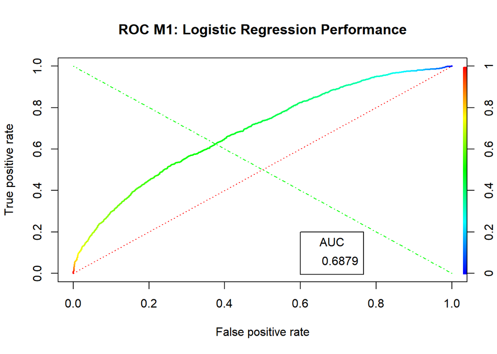

```r
# because of P values small, confidet level significant
M1_prediction <- prediction (p2, test_rose$flag_kredit_macet)
M1_Performance <- performance (M1_prediction, "tpr", "fpr")

#ROC
plot(M1_Performance, lwd=2, colorize=TRUE, main="ROC M1: Logistic Regression Performance")
lines(x=c(0, 1), y=c(0, 1), col="red", lwd=1, lty=3);
lines(x=c(1, 0), y=c(0, 1), col="green", lwd=1, lty=4)

#AUC
auc <- performance(M1_prediction, measure = "auc")
auc <- unlist(slot(auc, "y.values"))
auc <- round(auc,4)
legend(.6,.2, auc, title = "AUC")
```

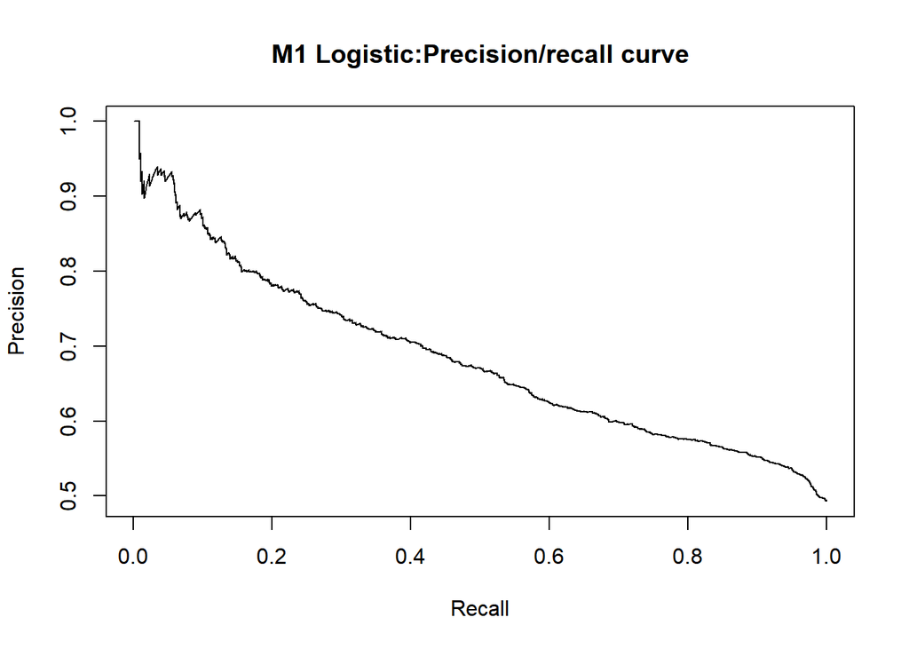

```r
#Plot Precision/recall Curve
M1_Perf_precision <- performance(M1_prediction, measure = "prec", x.measure = "rec")
plot(M1_Perf_precision, main="M1 Logistic:Precision/recall curve")
```

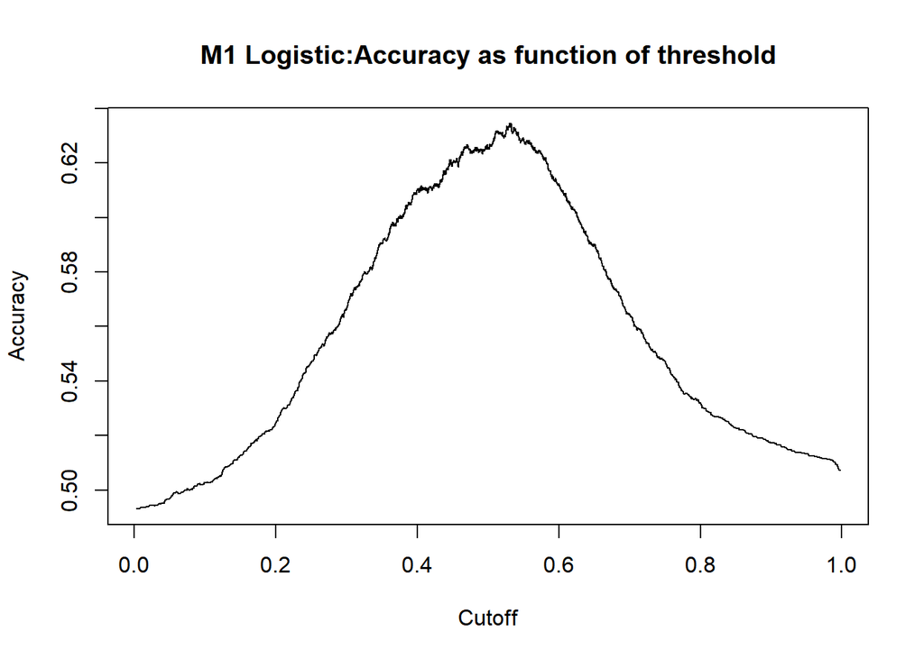

```r
#Plot accuracy
M1_Perf_acc <- performance(M1_prediction, measure = "acc")
plot(M1_Perf_acc, main="M1 Logistic:Accuracy as function of threshold")
```

```r
max <- which.max (slot(M1_Perf_acc, "y.values")[[1]])
acc <- slot(M1_Perf_acc, "y.values")[[1]][max]
acc
```

```
## [1] 0.6345652
```

```r
cutoff <- slot(M1_Perf_acc,"x.values")[[1]][max]
cutoff
```

```
##     14333
## 0.5327418
```

```r
#KS, Gini, AUC M1
M1_KS <- round(max(attr(M1_Performance,'y.values')[[1]]-attr(M1_Performance,'x.values')[[1]])*100, 2)
M1_AUROC <- round(performance(M1_prediction, measure = "auc")@y.values[[1]]*100, 2)
M1_Gini <- (2*M1_AUROC - 100)
cat("AUROC: ",M1_AUROC,"\tKS: ", M1_KS, "\tGini:", M1_Gini, "\n")
```

```
## AUROC:  68.79    KS:  26.61  Gini: 37.58
```

2. Random Forest Random forests are very good in that it is an ensemble learning method used for classification and regression. It uses multiple models for better performance that just using a single tree model. In addition because many sample are selected in the process a measure of variable importance can be obtain and this approach can be used for model selection.

```r
data_ROSE <- ROSE(flag_kredit_macet~ ., data = Credit_Scoring, seed = 123)$data
table(data_ROSE$flag_kredit_macet)
```

```
##
##    0    1
## 7873 7620
```

```r
set.seed(123)
sample <-sample(2, nrow(data_ROSE), replace = T, prob = c(0.7,0.3))
train_rose <- data_ROSE [sample==1,]
test_rose <- data_ROSE[sample==2,]

#Random Forest Model
set.seed(123)
M2 <- randomForest(flag_kredit_macet~., data = train_rose)
print(M2)
```

```
##
## Call:
##  randomForest(formula = flag_kredit_macet ~ ., data = train_rose)
##                Type of random forest: classification
##                      Number of trees: 500
## No. of variables tried at each split: 4
##
##         OOB estimate of  error rate: 5.64%
## Confusion matrix:
##      0    1 class.error
## 0 5147  394  0.07110630
## 1  220 5132  0.04110613
```

```r
attributes(M2)
```

```
## $names
##  [1] "call"            "type"            "predicted"       "err.rate"
##  [5] "confusion"       "votes"           "oob.times"       "classes"
##  [9] "importance"      "importanceSD"    "localImportance" "proximity"
## [13] "ntree"           "mtry"            "forest"          "y"
## [17] "test"            "inbag"           "terms"
##
## $class
## [1] "randomForest.formula" "randomForest"
```

```r
M2$confusion
```

```
##      0    1 class.error
## 0 5147  394  0.07110630
## 1  220 5132  0.04110613
```

```r
#Prediction & confusion Matrix- train data
p1_rf <- predict(M2, train_rose)
confusionMatrix(p1_rf, train_rose$flag_kredit_macet)
```

```
## Confusion Matrix and Statistics
##
##           Reference
## Prediction    0    1
##          0 5541    0
##          1    0 5352
##
##                Accuracy : 1
##                  95% CI : (0.9997, 1)
##     No Information Rate : 0.5087
##     P-Value [Acc > NIR] : < 2.2e-16
##
##                   Kappa : 1
##
##  Mcnemar's Test P-Value : NA
##
##             Sensitivity : 1.0000
##             Specificity : 1.0000
##          Pos Pred Value : 1.0000
##          Neg Pred Value : 1.0000
##              Prevalence : 0.5087
##          Detection Rate : 0.5087
##    Detection Prevalence : 0.5087
##       Balanced Accuracy : 1.0000
##
##        'Positive' Class : 0
##
```

```r
#Prediction & confusion matrix - test data
p2_rf <- predict(M2, test_rose)
confusionMatrix(p2_rf, test_rose$flag_kredit_macet)
```

```
## Confusion Matrix and Statistics
##
##           Reference
## Prediction    0    1
##          0 2157  100
##          1  175 2168
##
##                Accuracy : 0.9402
##                  95% CI : (0.933, 0.9469)
##     No Information Rate : 0.507
##     P-Value [Acc > NIR] : < 2.2e-16
##
##                   Kappa : 0.8805
##
##  Mcnemar's Test P-Value : 8.106e-06
##
##             Sensitivity : 0.9250
##             Specificity : 0.9559
##          Pos Pred Value : 0.9557
##          Neg Pred Value : 0.9253
##              Prevalence : 0.5070
##          Detection Rate : 0.4689
##    Detection Prevalence : 0.4907
##       Balanced Accuracy : 0.9404
##
##        'Positive' Class : 0
##
```

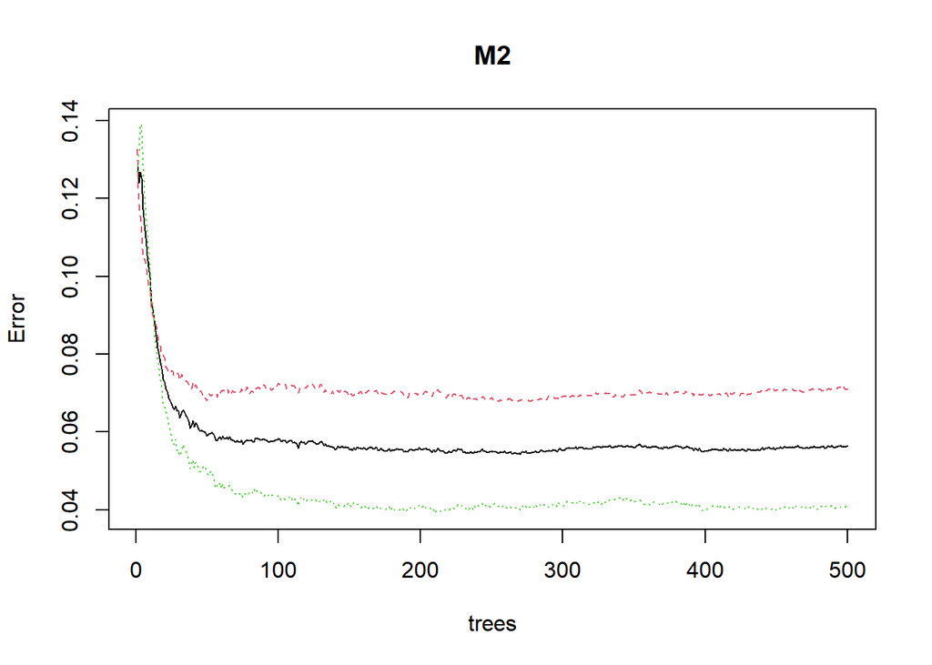

```r
#Error rate of Random FOrest
plot(M2)
```

```
## mtry = 5  OOB error = 0.1723856
## Searching left ...
## mtry = 10    OOB error = 0.16874
## 0.02114822 0.05
## Searching right ...
## mtry = 2     OOB error = 0.1801894
## -0.04526922 0.05
```

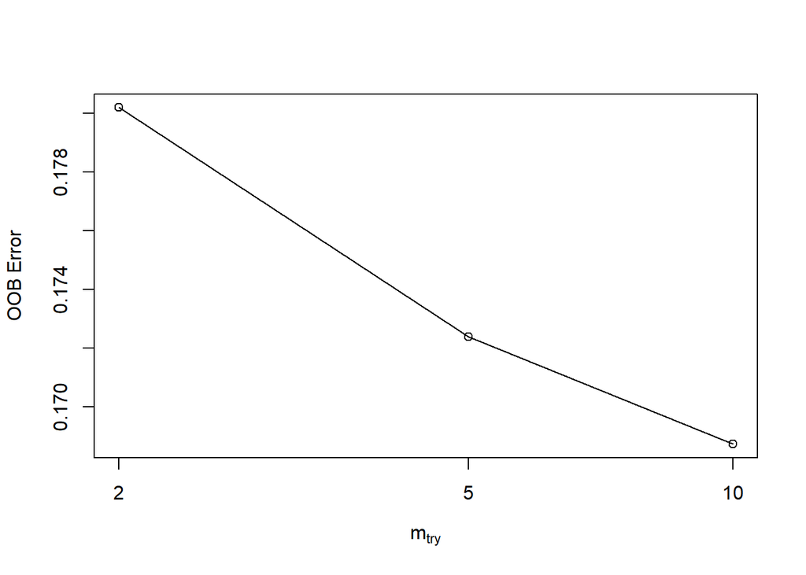

```r
#Tune mtry
t <- tuneRF(train_rose[,-18], train_rose[,18],
       stepFactor = 0.5,
       plot = TRUE,
       ntreeTry = 250,
       trace = TRUE,
       improve = 0.05)
```

```r
#improve the model based on tuning parameters
set.seed(123)
M2A <- randomForest(flag_kredit_macet~., data = train_rose,
                    ntree =300,
                    mtry =10,
                    importance= TRUE,
                    proximity = TRUE)

print (M2A)
```

```
##
## Call:
##  randomForest(formula = flag_kredit_macet ~ ., data = train_rose,      ntree = 300, mtry = 10, importance = TRUE, proximity = TRUE)
##                Type of random forest: classification
##                      Number of trees: 300
## No. of variables tried at each split: 10
##
##         OOB estimate of  error rate: 6.07%
## Confusion matrix:
##      0    1 class.error
## 0 5093  448  0.08085183
## 1  213 5139  0.03979821
```

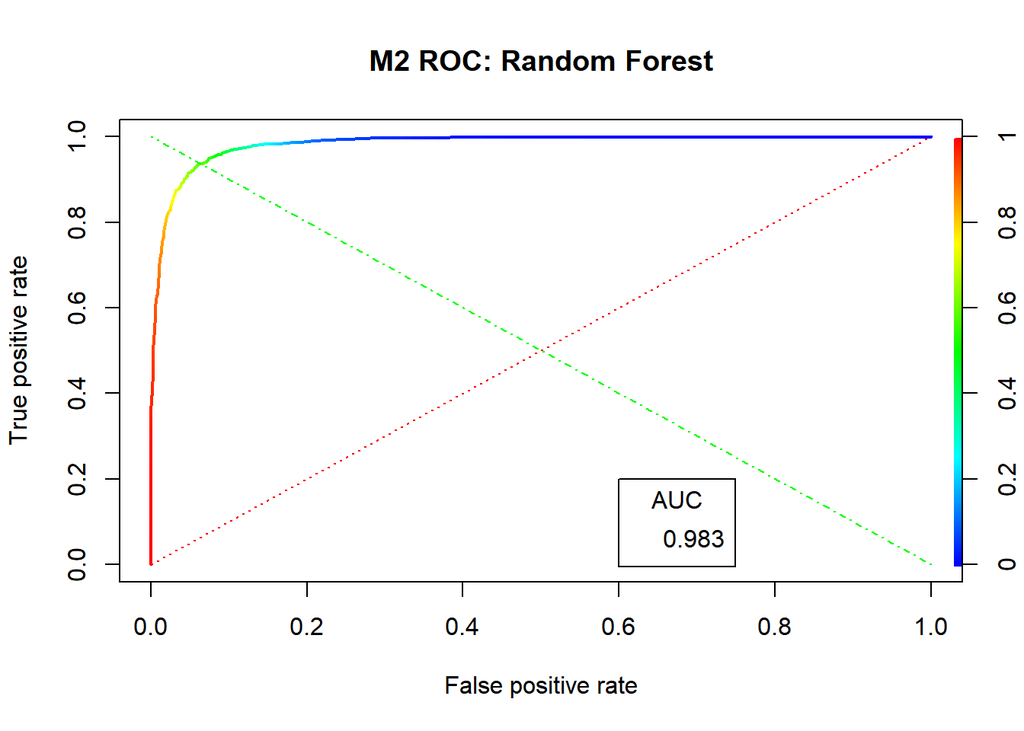

```r
#Prediction using M2A model after tuning

M2A_fitForest <- predict (M2A, newdata = test_rose, type ="prob") [,2]

M2A_pred <- prediction (M2A_fitForest, test_rose$flag_kredit_macet)
M2A_perf <- performance (M2A_pred, "tpr", "fpr")


#Model Performance Plot
#ROC
plot(M2A_perf,colorize=TRUE, lwd=2, main = "M2 ROC: Random Forest", col = "blue")
lines(x=c(0, 1), y=c(0, 1), col="red", lwd=1, lty=3);
lines(x=c(1, 0), y=c(0, 1), col="green", lwd=1, lty=4)

#AUC
auc <- performance(M2A_pred, measure = "auc")
auc <- unlist(slot(auc, "y.values"))
auc <- round(auc,4)
legend(.6,.2, auc, title = "AUC")
```

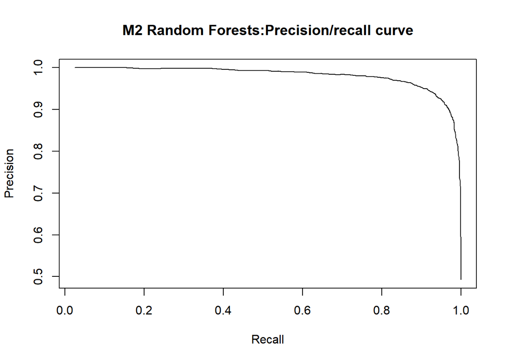

```r
# Plot precision/recall curve
M2A_perf_precision <- performance(M2A_pred, measure = "prec", x.measure = "rec")
plot(M2A_perf_precision, main="M2 Random Forests:Precision/recall curve")
```

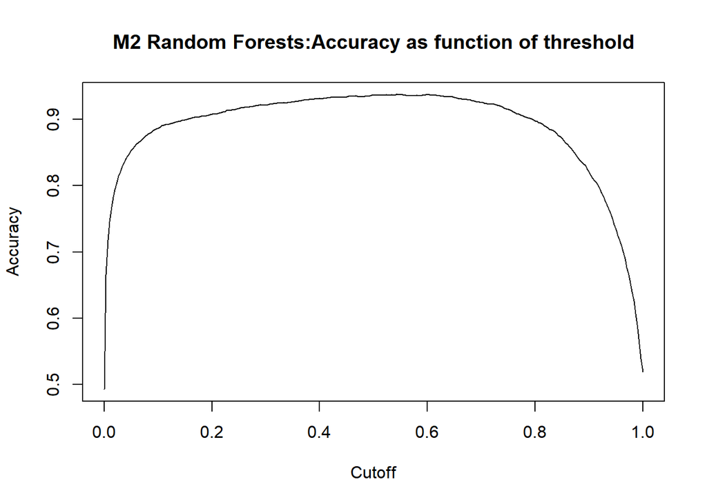

```r
# Plot accuracy as function of threshold
M2A_perf_acc <- performance(M2A_pred, measure = "acc")
plot(M2A_perf_acc, main="M2 Random Forests:Accuracy as function of threshold")
```

```r
max <- which.max (slot(M2A_perf_acc, "y.values")[[1]])
acc <- slot(M2A_perf_acc, "y.values")[[1]][max]
acc
```

```
## [1] 0.9373913
```

```r
#KS & AUC  m3
M2A_AUROC <- round(performance(M2A_pred, measure = "auc")@y.values[[1]]*100, 2)
M2A_KS <- round(max(attr(M2A_perf,'y.values')[[1]] - attr(M2A_perf,'x.values')[[1]])*100, 2)
M2A_Gini <- (2*M2A_AUROC - 100)
cat("AUROC: ",M2A_AUROC,"\tKS: ", M2A_KS, "\tGini:", M2A_Gini, "\n")
```

```
## AUROC:  98.3     KS:  87.51  Gini: 96.6
```

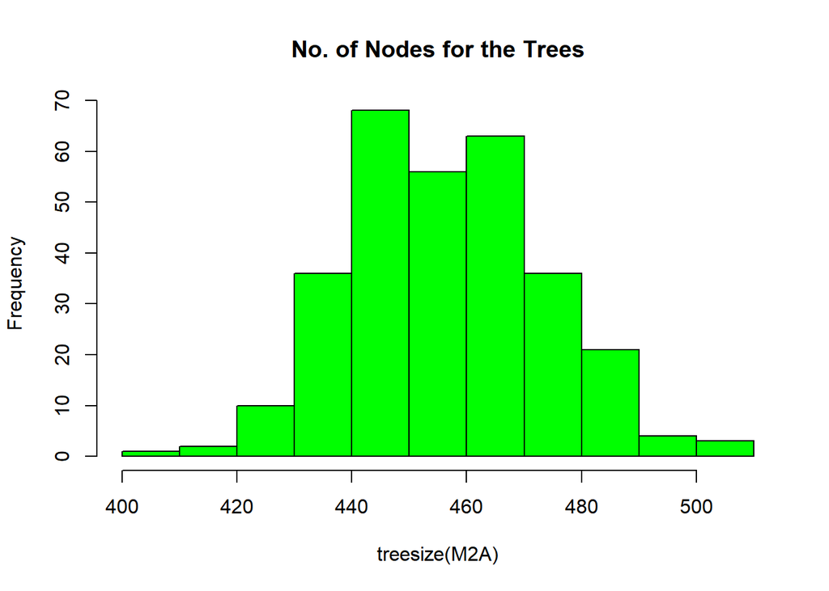

```r
# No of nodes for the trees
hist(treesize(M2A),
     main = "No. of Nodes for the Trees",
     col = "green")
```

[figure not shown]

```r
#variable of importance
varImpPlot(M2A,
           sort = T,
           main = "Variable of Importance")
```

```r
varUsed(M2A)
```

```
##  [1]  8597  8106  8386  8209 12109  7464 11602 10078  6374  8109  8014  6388
## [13]  8889  7049  6078  5846  5403
```

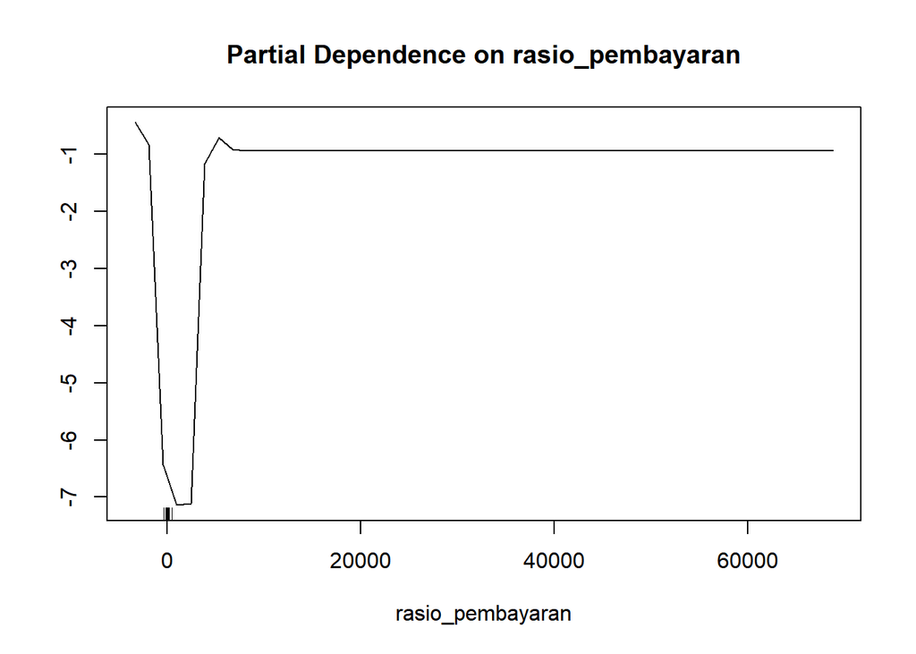

```r
#partial Dependence Plot
partialPlot(M2A, train_rose, rasio_pembayaran,"1")
```

3. SVM A Support Vector Machine (SVM) performs classification by constructing an N-dimensional hyperplane that optimally separates the data into two categories

```r
data_ROSE <- ROSE(flag_kredit_macet~ ., data = Credit_Scoring, seed = 123)$data
table(data_ROSE$flag_kredit_macet)
```

```
##
##    0    1
## 7873 7620
```

```r
data_ROSE$flag_kredit_macet <- as.factor(data_ROSE$flag_kredit_macet)
str(data_ROSE)
```

```
## 'data.frame':    15493 obs. of  18 variables:
##  $ outstanding                        : num  -3933143 28000825 -443459 762613 2182870 ...
##  $ tagihan                            : num  314515 5320588 -150527 8381693 1417965 ...
##  $ total_pemakaian_retail             : num  1721879 12982282 -230278 -4467728 6729680 ...
##  $ sisa_tagihan_tidak_terbayar        : num  5922583 -8967720 18732896 25349371 -7351427 ...
##  $ rasio_pembayaran                   : num  232 887 -1299 357 394 ...
##  $ persentasi_overlimit               : num  -6.25 1.02 -2.71 -5.06 7.69 ...
##  $ rasio_pembayaran_3bulan            : num  -1167 -665 653 -518 665 ...
##  $ rasio_pembayaran_6bulan            : num  1465 189 923 -768 -447 ...
##  $ flag_kredit_macet                  : Factor w/ 2 levels "0","1": 1 1 1 1 1 1 1 1 1 1 ...
##  $ jumlah_tahun_sejak_pembukaan_kredit: num  3.61 5.25 22.52 1.04 5.15 ...
##  $ total_pemakaian                    : num  -5939689 -2057 -1060414 7499636 1500441 ...
##  $ sisa_tagihan_per_jumlah_kartu      : num  -479402 -2726158 3717896 -2753981 -1791887 ...
##  $ sisa_tagihan_per_limit             : num  0.163 -0.375 -0.146 -0.305 1.381 ...
##  $ total_pemakaian_per_limit          : num  0.2003 0.0737 0.1292 0.116 0.5824 ...
##  $ pemakaian_3bln_per_limit           : num  0.05078 0.05473 -0.14572 0.00527 0.66387 ...
##  $ pemakaian_6bln_per_limit           : num  0.15 0.867 0.131 -0.21 0.498 ...
##  $ utilisasi_3bulan                   : num  -0.154 0.733 0.378 0.192 0.712 ...
##  $ utilisasi_6bulan                   : num  -0.2491 0.4041 0.5523 -0.1076 0.0127 ...
```

```r
set.seed(123)
sample <-sample(c(TRUE, FALSE), nrow(data_ROSE), replace = T, prob = c(0.7,0.3))
train_rose <- data_ROSE [sample,]
test_rose <- data_ROSE[!sample,]


M3 <- ksvm(flag_kredit_macet ~ ., data = train_rose, kernel = "vanilladot")
M3_pred <- predict(M3, test_rose [,1:18], type="response")
head(M3_pred)
```

```
## [1] 0 0 0 1 0 1
## Levels: 0 1
```

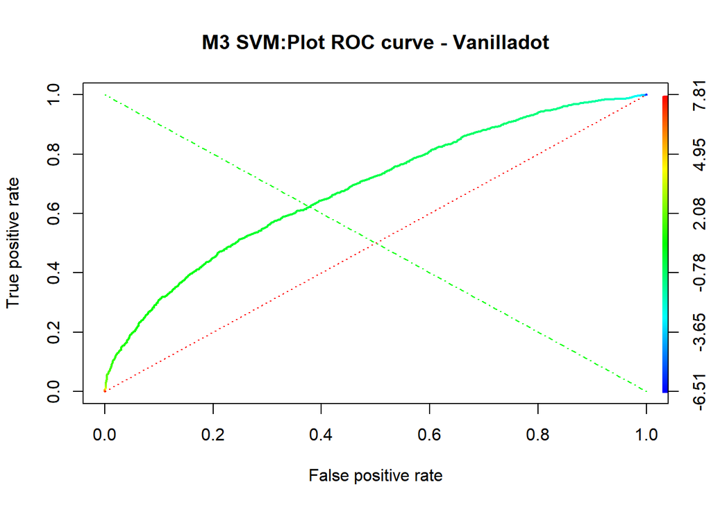

```r
M3_score <- predict(M3, test_rose, type = "decision")
M3_pred <- prediction (M3_score, test_rose$flag_kredit_macet)


M3_perf <- performance(M3_pred, measure = "tpr", x.measure = "fpr")
plot(M3_perf, colorize=TRUE, lwd=2, main="M3 SVM:Plot ROC curve - Vanilladot")
lines(x=c(0, 1), y=c(0, 1), col="red", lwd=1, lty=3);
lines(x=c(1, 0), y=c(0, 1), col="green", lwd=1, lty=4)
```

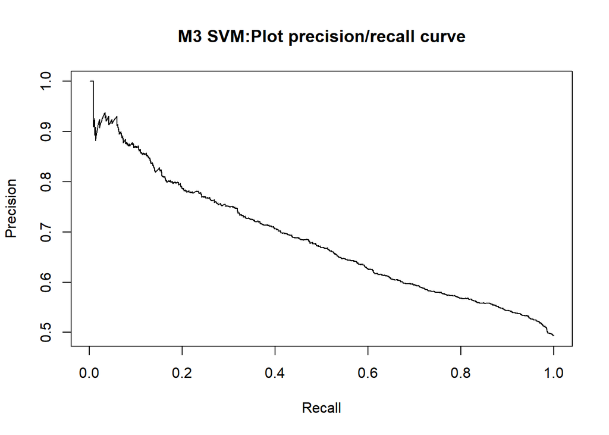

```r
# Plot precision/recall curve
M3_perf_precision <- performance(M3_pred, measure = "prec", x.measure = "rec")
plot(M3_perf_precision, main="M3 SVM:Plot precision/recall curve")
```

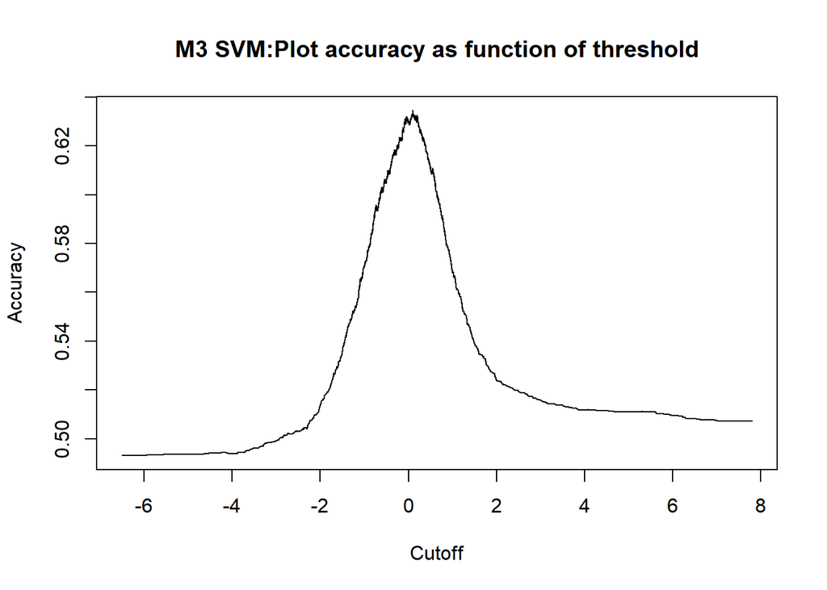

```r
# Plot accuracy as function of threshold
M3_perf_acc <- performance(M3_pred, measure = "acc")
plot(M3_perf_acc, main="M3 SVM:Plot accuracy as function of threshold")
```

```r
# Model Performance

#KS & AUC M3
M3_AUROC <- round(performance(M3_pred, measure = "auc")@y.values[[1]]*100, 2)
M3_KS <- round(max(attr(M3_perf,'y.values')[[1]]-attr(M3_perf,'x.values')[[1]])*100, 2)
M3_Gini <- (2*M3_AUROC - 100)
cat("AUROC: ",M3_AUROC,"\tKS: ", M3_KS, "\tGini:", M3_Gini, "\n")
```

```
## AUROC:  68.4     KS:  26.58  Gini: 36.8
```

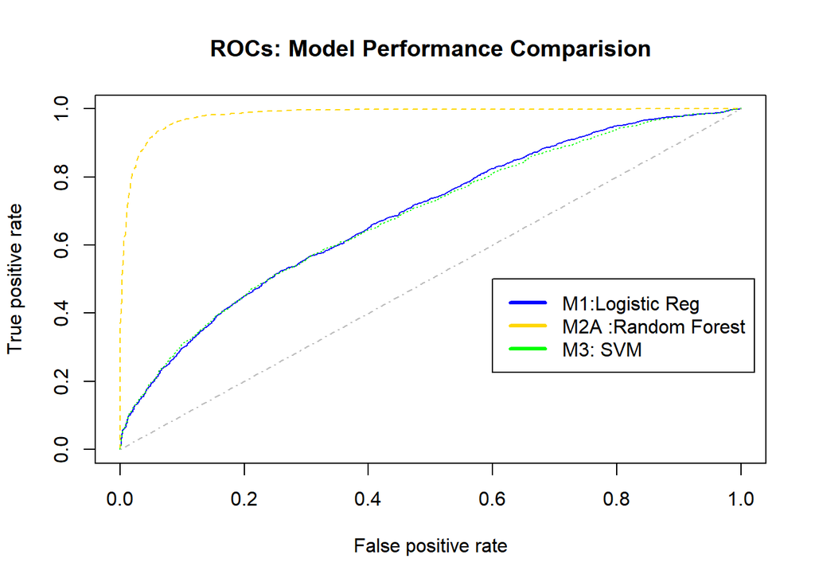

```r
#Compare ROC Performance of Models
plot(M1_Performance, col='blue', lty=1, main='ROCs: Model Performance Comparision') # logistic regression
plot(M2A_perf, col='gold',lty=2, add=TRUE);
plot(M3_perf, col='green',add=TRUE,lty=3);
    legend(0.6,0.5,
           c('M1:Logistic Reg','M2A :Random Forest',
              'M3: SVM'),
           col=c('blue','gold', 'green'),
           lwd=3);
lines(c(0,1),c(0,1),col = "gray", lty = 4 ) # random line
```

```r
# Performance Table
models <- c('M1:Logistic Regression',
           'M2A:Random Forest','M3:SVM')

# AUCs
models_AUC <- c(M1_AUROC, M2A_AUROC, M3_AUROC)
# KS
models_KS <- c(M1_KS, M2A_KS, M3_KS )

# Gini
models_Gini <- c(M1_Gini, M2A_Gini, M3_Gini)

# Combine AUC and KS
model_performance_metric <- as.data.frame(cbind(models, models_AUC, models_KS, models_Gini))

# Colnames
colnames(model_performance_metric) <- c("Model", "AUC", "KS", "Gini")

# Display Performance Reports
kable(model_performance_metric, caption ="Comparision of Model Performances")
```

Comparision of Model Performances

| Model | AUC | KS | Gini |
| --- | --- | --- | --- |
| M1:Logistic Regression | 68.79 | 26.61 | 37.58 |
| M2A:Random Forest | 98.3 | 87.51 | 96.6 |
| M3:SVM | 68.4 | 26.58 | 36.8 |